# Project_0520

```python
import numpy as np
import pandas as pd

from sklearn.tree import DecisionTreeClassifier
from sklearn.linear_model import LogisticRegression
from sklearn.naive_bayes import BernoulliNB, MultinomialNB, GaussianNB
from sklearn import svm

from sklearn import metrics
from sklearn.model_selection import cross_val_score
from sklearn.model_selection import train_test_split

from sklearn import datasets

from scipy.spatial.distance import pdist, squareform
from scipy.cluster.hierarchy import linkage, dendrogram

from sklearn.cluster import KMeans
from sklearn.neighbors import KNeighborsClassifier
from scipy.spatial import distance

import matplotlib.pyplot as plt

from sklearn.metrics import fbeta_score
import seaborn as sns

from sklearn.ensemble import BaggingClassifier
from sklearn.neighbors import KNeighborsClassifier
from sklearn.tree import DecisionTreeClassifier
from sklearn import model_selection
from sklearn import tree

from copy import copy
from sklearn.decomposition import PCA, TruncatedSVD

from sklearn.ensemble import RandomForestClassifier
from sklearn.datasets import make_classification

%matplotlib inline
plt.rcParams['figure.figsize'] = 10, 8
```

## data cleaning

### data features analysis

```python
# Let's read the file
#df = pd.read_csv("notes/default of credit card clients.csv",  header=0)
df = pd.read_csv("data/default of credit card clients.csv",  header=0)
```

```python
#info
df.info()
```

```
<class 'pandas.core.frame.DataFrame'>
RangeIndex: 30000 entries, 0 to 29999
Data columns (total 25 columns):
ID           30000 non-null int64
LIMIT_BAL    30000 non-null int64
SEX          30000 non-null int64
EDUCATION    30000 non-null int64
MARRIAGE     30000 non-null int64
AGE          30000 non-null int64
PAY_0        30000 non-null int64
PAY_2        30000 non-null int64
PAY_3        30000 non-null int64
PAY_4        30000 non-null int64
PAY_5        30000 non-null int64
PAY_6        30000 non-null int64
BILL_AMT1    30000 non-null int64
BILL_AMT2    30000 non-null int64
BILL_AMT3    30000 non-null int64
BILL_AMT4    30000 non-null int64
BILL_AMT5    30000 non-null int64
BILL_AMT6    30000 non-null int64
PAY_AMT1     30000 non-null int64
PAY_AMT2     30000 non-null int64
PAY_AMT3     30000 non-null int64
PAY_AMT4     30000 non-null int64
PAY_AMT5     30000 non-null int64
PAY_AMT6     30000 non-null int64
Class        30000 non-null int64
dtypes: int64(25)
memory usage: 5.7 MB
```

```python
# Let's print the top-5 rows
df.head()
```

|  | ID | LIMIT_BAL | SEX | EDUCATION | MARRIAGE | AGE | PAY_0 | PAY_2 | PAY_3 | PAY_4 | ... | BILL_AMT4 | BILL_AMT5 | BILL_AMT6 | PAY_AMT1 | PAY_AMT2 | PAY_AMT3 | PAY_AMT4 | PAY_AMT5 | PAY_AMT6 | Class |
| --- | --- | --- | --- | --- | --- | --- | --- | --- | --- | --- | --- | --- | --- | --- | --- | --- | --- | --- | --- | --- | --- |
| 0 | 1 | 20000 | 2 | 2 | 1 | 24 | 2 | 2 | -1 | -1 | ... | 0 | 0 | 0 | 0 | 689 | 0 | 0 | 0 | 0 | 1 |
| 1 | 2 | 120000 | 2 | 2 | 2 | 26 | -1 | 2 | 0 | 0 | ... | 3272 | 3455 | 3261 | 0 | 1000 | 1000 | 1000 | 0 | 2000 | 1 |
| 2 | 3 | 90000 | 2 | 2 | 2 | 34 | 0 | 0 | 0 | 0 | ... | 14331 | 14948 | 15549 | 1518 | 1500 | 1000 | 1000 | 1000 | 5000 | 0 |
| 3 | 4 | 50000 | 2 | 2 | 1 | 37 | 0 | 0 | 0 | 0 | ... | 28314 | 28959 | 29547 | 2000 | 2019 | 1200 | 1100 | 1069 | 1000 | 0 |
| 4 | 5 | 50000 | 1 | 2 | 1 | 57 | -1 | 0 | -1 | 0 | ... | 20940 | 19146 | 19131 | 2000 | 36681 | 10000 | 9000 | 689 | 679 | 0 |

5 rows × 25 columns

ID could not be used as a feature since it is unique for each person and meaningless. Hence we should drop it.

```python
df= df.drop(['ID'], axis=1)
```

```python
#numerical summary -> only non-anonymized columns of interest
pd.set_option('precision', 3)
df.loc[:, ['BILL_AMT1', 'BILL_AMT2']].describe()
```

|  | BILL_AMT1 | BILL_AMT2 |
| --- | --- | --- |
| count | 30000.000 | 30000.000 |
| mean | 51223.331 | 49179.075 |
| std | 73635.861 | 71173.769 |
| min | -165580.000 | -69777.000 |
| 25% | 3558.750 | 2984.750 |
| 50% | 22381.500 | 21200.000 |
| 75% | 67091.000 | 64006.250 |
| max | 964511.000 | 983931.000 |

```python
#number of each transactions
counts = df.Class.value_counts()
normal = counts[0]
fraudulent = counts[1]
perc_normal = (normal/(normal+fraudulent))*100
perc_fraudulent = (fraudulent/(normal+fraudulent))*100
print('There were {} non-fraudulent transactions ({:.3f}%) and {} fraudulent transactions ({:.3f}%).'.format(normal, perc_normal, fraudulent, perc_fraudulent))
```

```
There were 23364 non-fraudulent transactions (77.880%) and 6636 fraudulent transactions (22.120%).
```

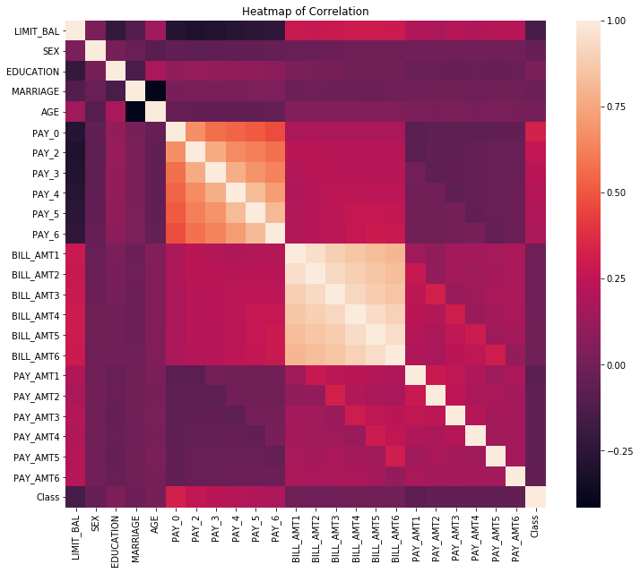

```python
#heatmap
corr = df.corr()
plt.figure(figsize=(12,10))
heat = sns.heatmap(data=corr)
plt.title('Heatmap of Correlation')
```

```python
corr.style.background_gradient(cmap='coolwarm')
```

|  | LIMIT_BAL | SEX | EDUCATION | MARRIAGE | AGE | PAY_0 | PAY_2 | PAY_3 | PAY_4 | PAY_5 | PAY_6 | BILL_AMT1 | BILL_AMT2 | BILL_AMT3 | BILL_AMT4 | BILL_AMT5 | BILL_AMT6 | PAY_AMT1 | PAY_AMT2 | PAY_AMT3 | PAY_AMT4 | PAY_AMT5 | PAY_AMT6 | Class |
| --- | --- | --- | --- | --- | --- | --- | --- | --- | --- | --- | --- | --- | --- | --- | --- | --- | --- | --- | --- | --- | --- | --- | --- | --- |
| LIMIT_BAL | 1 | 0.0248 | -0.219 | -0.108 | 0.145 | -0.271 | -0.296 | -0.286 | -0.267 | -0.249 | -0.235 | 0.285 | 0.278 | 0.283 | 0.294 | 0.296 | 0.29 | 0.195 | 0.178 | 0.21 | 0.203 | 0.217 | 0.22 | -0.154 |
| SEX | 0.0248 | 1 | 0.0142 | -0.0314 | -0.0909 | -0.0576 | -0.0708 | -0.0661 | -0.0602 | -0.0551 | -0.044 | -0.0336 | -0.0312 | -0.0246 | -0.0219 | -0.017 | -0.0167 | -0.000242 | -0.00139 | -0.0086 | -0.00223 | -0.00167 | -0.00277 | -0.04 |
| EDUCATION | -0.219 | 0.0142 | 1 | -0.143 | 0.175 | 0.105 | 0.122 | 0.114 | 0.109 | 0.0975 | 0.0823 | 0.0236 | 0.0187 | 0.013 | -0.000451 | -0.00757 | -0.0091 | -0.0375 | -0.03 | -0.0399 | -0.0382 | -0.0404 | -0.0372 | 0.028 |
| MARRIAGE | -0.108 | -0.0314 | -0.143 | 1 | -0.414 | 0.0199 | 0.0242 | 0.0327 | 0.0331 | 0.0356 | 0.0343 | -0.0235 | -0.0216 | -0.0249 | -0.0233 | -0.0254 | -0.0212 | -0.00598 | -0.00809 | -0.00354 | -0.0127 | -0.0012 | -0.00664 | -0.0243 |
| AGE | 0.145 | -0.0909 | 0.175 | -0.414 | 1 | -0.0394 | -0.0501 | -0.053 | -0.0497 | -0.0538 | -0.0488 | 0.0562 | 0.0543 | 0.0537 | 0.0514 | 0.0493 | 0.0476 | 0.0261 | 0.0218 | 0.0292 | 0.0214 | 0.0228 | 0.0195 | 0.0139 |
| PAY_0 | -0.271 | -0.0576 | 0.105 | 0.0199 | -0.0394 | 1 | 0.672 | 0.574 | 0.539 | 0.509 | 0.475 | 0.187 | 0.19 | 0.18 | 0.179 | 0.181 | 0.177 | -0.0793 | -0.0701 | -0.0706 | -0.064 | -0.0582 | -0.0587 | 0.325 |
| PAY_2 | -0.296 | -0.0708 | 0.122 | 0.0242 | -0.0501 | 0.672 | 1 | 0.767 | 0.662 | 0.623 | 0.576 | 0.235 | 0.235 | 0.224 | 0.222 | 0.221 | 0.219 | -0.0807 | -0.059 | -0.0559 | -0.0469 | -0.0371 | -0.0365 | 0.264 |
| PAY_3 | -0.286 | -0.0661 | 0.114 | 0.0327 | -0.053 | 0.574 | 0.767 | 1 | 0.777 | 0.687 | 0.633 | 0.208 | 0.237 | 0.227 | 0.227 | 0.225 | 0.222 | 0.00129 | -0.0668 | -0.0533 | -0.0461 | -0.0359 | -0.0359 | 0.235 |
| PAY_4 | -0.267 | -0.0602 | 0.109 | 0.0331 | -0.0497 | 0.539 | 0.662 | 0.777 | 1 | 0.82 | 0.716 | 0.203 | 0.226 | 0.245 | 0.246 | 0.243 | 0.239 | -0.00936 | -0.00194 | -0.0692 | -0.0435 | -0.0336 | -0.0266 | 0.217 |
| PAY_5 | -0.249 | -0.0551 | 0.0975 | 0.0356 | -0.0538 | 0.509 | 0.623 | 0.687 | 0.82 | 1 | 0.817 | 0.207 | 0.227 | 0.243 | 0.272 | 0.27 | 0.263 | -0.00609 | -0.00319 | 0.00906 | -0.0583 | -0.0333 | -0.023 | 0.204 |
| PAY_6 | -0.235 | -0.044 | 0.0823 | 0.0343 | -0.0488 | 0.475 | 0.576 | 0.633 | 0.716 | 0.817 | 1 | 0.207 | 0.227 | 0.241 | 0.266 | 0.291 | 0.285 | -0.0015 | -0.00522 | 0.00583 | 0.019 | -0.0464 | -0.0253 | 0.187 |
| BILL_AMT1 | 0.285 | -0.0336 | 0.0236 | -0.0235 | 0.0562 | 0.187 | 0.235 | 0.208 | 0.203 | 0.207 | 0.207 | 1 | 0.951 | 0.892 | 0.86 | 0.83 | 0.803 | 0.14 | 0.0994 | 0.157 | 0.158 | 0.167 | 0.179 | -0.0196 |
| BILL_AMT2 | 0.278 | -0.0312 | 0.0187 | -0.0216 | 0.0543 | 0.19 | 0.235 | 0.237 | 0.226 | 0.227 | 0.227 | 0.951 | 1 | 0.928 | 0.892 | 0.86 | 0.832 | 0.28 | 0.101 | 0.151 | 0.147 | 0.158 | 0.174 | -0.0142 |
| BILL_AMT3 | 0.283 | -0.0246 | 0.013 | -0.0249 | 0.0537 | 0.18 | 0.224 | 0.227 | 0.245 | 0.243 | 0.241 | 0.892 | 0.928 | 1 | 0.924 | 0.884 | 0.853 | 0.244 | 0.317 | 0.13 | 0.143 | 0.18 | 0.182 | -0.0141 |
| BILL_AMT4 | 0.294 | -0.0219 | -0.000451 | -0.0233 | 0.0514 | 0.179 | 0.222 | 0.227 | 0.246 | 0.272 | 0.266 | 0.86 | 0.892 | 0.924 | 1 | 0.94 | 0.901 | 0.233 | 0.208 | 0.3 | 0.13 | 0.16 | 0.178 | -0.0102 |
| BILL_AMT5 | 0.296 | -0.017 | -0.00757 | -0.0254 | 0.0493 | 0.181 | 0.221 | 0.225 | 0.243 | 0.27 | 0.291 | 0.83 | 0.86 | 0.884 | 0.94 | 1 | 0.946 | 0.217 | 0.181 | 0.252 | 0.293 | 0.142 | 0.164 | -0.00676 |
| BILL_AMT6 | 0.29 | -0.0167 | -0.0091 | -0.0212 | 0.0476 | 0.177 | 0.219 | 0.222 | 0.239 | 0.263 | 0.285 | 0.803 | 0.832 | 0.853 | 0.901 | 0.946 | 1 | 0.2 | 0.173 | 0.234 | 0.25 | 0.308 | 0.115 | -0.00537 |
| PAY_AMT1 | 0.195 | -0.000242 | -0.0375 | -0.00598 | 0.0261 | -0.0793 | -0.0807 | 0.00129 | -0.00936 | -0.00609 | -0.0015 | 0.14 | 0.28 | 0.244 | 0.233 | 0.217 | 0.2 | 1 | 0.286 | 0.252 | 0.2 | 0.148 | 0.186 | -0.0729 |
| PAY_AMT2 | 0.178 | -0.00139 | -0.03 | -0.00809 | 0.0218 | -0.0701 | -0.059 | -0.0668 | -0.00194 | -0.00319 | -0.00522 | 0.0994 | 0.101 | 0.317 | 0.208 | 0.181 | 0.173 | 0.286 | 1 | 0.245 | 0.18 | 0.181 | 0.158 | -0.0586 |
| PAY_AMT3 | 0.21 | -0.0086 | -0.0399 | -0.00354 | 0.0292 | -0.0706 | -0.0559 | -0.0533 | -0.0692 | 0.00906 | 0.00583 | 0.157 | 0.151 | 0.13 | 0.3 | 0.252 | 0.234 | 0.252 | 0.245 | 1 | 0.216 | 0.159 | 0.163 | -0.0563 |
| PAY_AMT4 | 0.203 | -0.00223 | -0.0382 | -0.0127 | 0.0214 | -0.064 | -0.0469 | -0.0461 | -0.0435 | -0.0583 | 0.019 | 0.158 | 0.147 | 0.143 | 0.13 | 0.293 | 0.25 | 0.2 | 0.18 | 0.216 | 1 | 0.152 | 0.158 | -0.0568 |
| PAY_AMT5 | 0.217 | -0.00167 | -0.0404 | -0.0012 | 0.0228 | -0.0582 | -0.0371 | -0.0359 | -0.0336 | -0.0333 | -0.0464 | 0.167 | 0.158 | 0.18 | 0.16 | 0.142 | 0.308 | 0.148 | 0.181 | 0.159 | 0.152 | 1 | 0.155 | -0.0551 |
| PAY_AMT6 | 0.22 | -0.00277 | -0.0372 | -0.00664 | 0.0195 | -0.0587 | -0.0365 | -0.0359 | -0.0266 | -0.023 | -0.0253 | 0.179 | 0.174 | 0.182 | 0.178 | 0.164 | 0.115 | 0.186 | 0.158 | 0.163 | 0.158 | 0.155 | 1 | -0.0532 |
| Class | -0.154 | -0.04 | 0.028 | -0.0243 | 0.0139 | 0.325 | 0.264 | 0.235 | 0.217 | 0.204 | 0.187 | -0.0196 | -0.0142 | -0.0141 | -0.0102 | -0.00676 | -0.00537 | -0.0729 | -0.0586 | -0.0563 | -0.0568 | -0.0551 | -0.0532 | 1 |

```python
#taking a look at correlations
corr = df.corr()
corr = corr[['Class']]
corr
```

|  | Class |
| --- | --- |
| LIMIT_BAL | -0.154 |
| SEX | -0.040 |
| EDUCATION | 0.028 |
| MARRIAGE | -0.024 |
| AGE | 0.014 |
| PAY_0 | 0.325 |
| PAY_2 | 0.264 |
| PAY_3 | 0.235 |
| PAY_4 | 0.217 |
| PAY_5 | 0.204 |
| PAY_6 | 0.187 |
| BILL_AMT1 | -0.020 |
| BILL_AMT2 | -0.014 |
| BILL_AMT3 | -0.014 |
| BILL_AMT4 | -0.010 |
| BILL_AMT5 | -0.007 |
| BILL_AMT6 | -0.005 |
| PAY_AMT1 | -0.073 |
| PAY_AMT2 | -0.059 |
| PAY_AMT3 | -0.056 |
| PAY_AMT4 | -0.057 |
| PAY_AMT5 | -0.055 |
| PAY_AMT6 | -0.053 |
| Class | 1.000 |

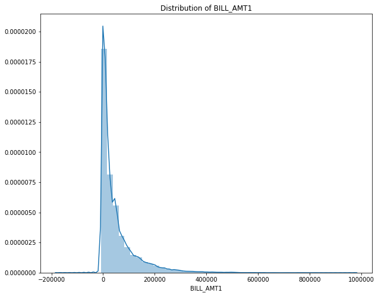

```python
plt.figure(figsize=(10,8))
plt.title('Distribution of BILL_AMT1')
sns.distplot(df.BILL_AMT1)
```

## Feature selection part

### Outlier Removal

```python
df_bill = df[['BILL_AMT1','BILL_AMT2','BILL_AMT3','BILL_AMT4','BILL_AMT5','BILL_AMT6']]
```

```python
#Only removing extreme outliers
Q1 = df_bill.quantile(0.25)
Q3 = df_bill.quantile(0.75)
IQR = Q3 - Q1

df2 = df[~((df_bill < (Q1 - 1.5 * IQR)) |(df_bill > (Q3 + 1.5* IQR))).any(axis=1)]
```

```python
df2.head()
```

|  | LIMIT_BAL | SEX | EDUCATION | MARRIAGE | AGE | PAY_0 | PAY_2 | PAY_3 | PAY_4 | PAY_5 | ... | BILL_AMT4 | BILL_AMT5 | BILL_AMT6 | PAY_AMT1 | PAY_AMT2 | PAY_AMT3 | PAY_AMT4 | PAY_AMT5 | PAY_AMT6 | Class |
| --- | --- | --- | --- | --- | --- | --- | --- | --- | --- | --- | --- | --- | --- | --- | --- | --- | --- | --- | --- | --- | --- |
| 0 | 20000 | 2 | 2 | 1 | 24 | 2 | 2 | -1 | -1 | -2 | ... | 0 | 0 | 0 | 0 | 689 | 0 | 0 | 0 | 0 | 1 |
| 1 | 120000 | 2 | 2 | 2 | 26 | -1 | 2 | 0 | 0 | 0 | ... | 3272 | 3455 | 3261 | 0 | 1000 | 1000 | 1000 | 0 | 2000 | 1 |
| 2 | 90000 | 2 | 2 | 2 | 34 | 0 | 0 | 0 | 0 | 0 | ... | 14331 | 14948 | 15549 | 1518 | 1500 | 1000 | 1000 | 1000 | 5000 | 0 |
| 3 | 50000 | 2 | 2 | 1 | 37 | 0 | 0 | 0 | 0 | 0 | ... | 28314 | 28959 | 29547 | 2000 | 2019 | 1200 | 1100 | 1069 | 1000 | 0 |
| 4 | 50000 | 1 | 2 | 1 | 57 | -1 | 0 | -1 | 0 | 0 | ... | 20940 | 19146 | 19131 | 2000 | 36681 | 10000 | 9000 | 689 | 679 | 0 |

5 rows × 24 columns

```python
len(df)-len(df2)
```

```
3767
```

```python
len_after = len(df2)
len_before = len(df)
len_difference = len(df) - len(df2)
print('We reduced our data size from {} transactions by {} transactions to {} transactions.'.format(len_before, len_difference, len_after))
```

```
We reduced our data size from 30000 transactions by 3767 transactions to 26233 transactions.
```

We plot the same feature and see what happens after the removal

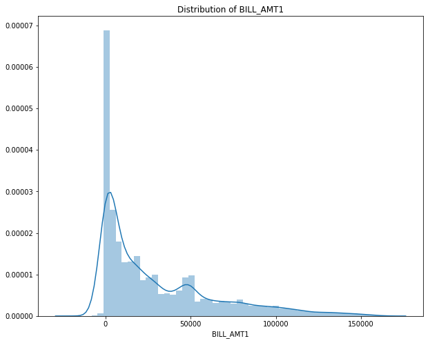

```python
plt.figure(figsize=(10,8))
plt.title('Distribution of BILL_AMT1')
sns.distplot(df2.BILL_AMT1)
```

```python
df["Class"].sum()-df2["Class"].sum()
```

```
717
```

```python
def add_feature(a, b):
    return a + b

df2['Diff_1'] = df2.apply(lambda row: add_feature(row['BILL_AMT1'], row['PAY_AMT1']), axis=1)
df2['Diff_2'] = df2.apply(lambda row: add_feature(row['BILL_AMT2'], row['PAY_AMT2']), axis=1)
df2['Diff_3'] = df2.apply(lambda row: add_feature(row['BILL_AMT3'], row['PAY_AMT3']), axis=1)
df2['Diff_4'] = df2.apply(lambda row: add_feature(row['BILL_AMT4'], row['PAY_AMT4']), axis=1)
df2['Diff_5'] = df2.apply(lambda row: add_feature(row['BILL_AMT5'], row['PAY_AMT5']), axis=1)
df2['Diff_6'] = df2.apply(lambda row: add_feature(row['BILL_AMT6'], row['PAY_AMT6']), axis=1)
df2.head()
```

[output not shown]

|  | LIMIT_BAL | SEX | EDUCATION | MARRIAGE | AGE | PAY_0 | PAY_2 | PAY_3 | PAY_4 | PAY_5 | ... | PAY_AMT4 | PAY_AMT5 | PAY_AMT6 | Class | Diff_1 | Diff_2 | Diff_3 | Diff_4 | Diff_5 | Diff_6 |
| --- | --- | --- | --- | --- | --- | --- | --- | --- | --- | --- | --- | --- | --- | --- | --- | --- | --- | --- | --- | --- | --- |
| 0 | 20000 | 2 | 2 | 1 | 24 | 2 | 2 | -1 | -1 | -2 | ... | 0 | 0 | 0 | 1 | 3913 | 3791 | 689 | 0 | 0 | 0 |
| 1 | 120000 | 2 | 2 | 2 | 26 | -1 | 2 | 0 | 0 | 0 | ... | 1000 | 0 | 2000 | 1 | 2682 | 2725 | 3682 | 4272 | 3455 | 5261 |
| 2 | 90000 | 2 | 2 | 2 | 34 | 0 | 0 | 0 | 0 | 0 | ... | 1000 | 1000 | 5000 | 0 | 30757 | 15527 | 14559 | 15331 | 15948 | 20549 |
| 3 | 50000 | 2 | 2 | 1 | 37 | 0 | 0 | 0 | 0 | 0 | ... | 1100 | 1069 | 1000 | 0 | 48990 | 50252 | 50491 | 29414 | 30028 | 30547 |
| 4 | 50000 | 1 | 2 | 1 | 57 | -1 | 0 | -1 | 0 | 0 | ... | 9000 | 689 | 679 | 0 | 10617 | 42351 | 45835 | 29940 | 19835 | 19810 |

5 rows × 30 columns

```python
corr = df2.corr()
corr = corr[['Class']]
corr
```

|  | Class |
| --- | --- |
| LIMIT_BAL | -1.613e-01 |
| SEX | -4.074e-02 |
| EDUCATION | 3.497e-02 |
| MARRIAGE | -2.480e-02 |
| AGE | 1.753e-02 |
| PAY_0 | 3.173e-01 |
| PAY_2 | 2.589e-01 |
| PAY_3 | 2.323e-01 |
| PAY_4 | 2.188e-01 |
| PAY_5 | 2.054e-01 |
| PAY_6 | 1.898e-01 |
| BILL_AMT1 | -2.609e-02 |
| BILL_AMT2 | -1.566e-02 |
| BILL_AMT3 | -1.073e-02 |
| BILL_AMT4 | -5.507e-03 |
| BILL_AMT5 | 1.608e-04 |
| BILL_AMT6 | 8.372e-03 |
| PAY_AMT1 | -9.520e-02 |
| PAY_AMT2 | -9.136e-02 |
| PAY_AMT3 | -8.469e-02 |
| PAY_AMT4 | -7.097e-02 |
| PAY_AMT5 | -7.168e-02 |
| PAY_AMT6 | -6.622e-02 |
| Class | 1.000e+00 |
| Diff_1 | -5.008e-02 |
| Diff_2 | -4.159e-02 |
| Diff_3 | -3.466e-02 |
| Diff_4 | -2.620e-02 |
| Diff_5 | -2.154e-02 |
| Diff_6 | -2.087e-02 |

### data processing

```python
#get features and labels
def separate_features_and_labels(dframe):
    labels = dframe['Class']
    features = dframe.drop(columns = ["Class"])
    return features, labels
df_f,df_l=separate_features_and_labels(df2)
```

```python
df_f.head()
```

|  | LIMIT_BAL | SEX | EDUCATION | MARRIAGE | AGE | PAY_0 | PAY_2 | PAY_3 | PAY_4 | PAY_5 | ... | PAY_AMT3 | PAY_AMT4 | PAY_AMT5 | PAY_AMT6 | Diff_1 | Diff_2 | Diff_3 | Diff_4 | Diff_5 | Diff_6 |
| --- | --- | --- | --- | --- | --- | --- | --- | --- | --- | --- | --- | --- | --- | --- | --- | --- | --- | --- | --- | --- | --- |
| 0 | 20000 | 2 | 2 | 1 | 24 | 2 | 2 | -1 | -1 | -2 | ... | 0 | 0 | 0 | 0 | 3913 | 3791 | 689 | 0 | 0 | 0 |
| 1 | 120000 | 2 | 2 | 2 | 26 | -1 | 2 | 0 | 0 | 0 | ... | 1000 | 1000 | 0 | 2000 | 2682 | 2725 | 3682 | 4272 | 3455 | 5261 |
| 2 | 90000 | 2 | 2 | 2 | 34 | 0 | 0 | 0 | 0 | 0 | ... | 1000 | 1000 | 1000 | 5000 | 30757 | 15527 | 14559 | 15331 | 15948 | 20549 |
| 3 | 50000 | 2 | 2 | 1 | 37 | 0 | 0 | 0 | 0 | 0 | ... | 1200 | 1100 | 1069 | 1000 | 48990 | 50252 | 50491 | 29414 | 30028 | 30547 |
| 4 | 50000 | 1 | 2 | 1 | 57 | -1 | 0 | -1 | 0 | 0 | ... | 10000 | 9000 | 689 | 679 | 10617 | 42351 | 45835 | 29940 | 19835 | 19810 |

5 rows × 29 columns

```python
def normalize(X):
    """
    Make the distribution of the values of each variable similar by subtracting the mean and by dividing by the standard deviation.
    """
    for feature in X.columns:
        X[feature] -= X[feature].mean()
        X[feature] /= X[feature].std()
    return X

#normalize df
df_f = normalize(df_f)
```

```python
df_f.head()
```

|  | LIMIT_BAL | SEX | EDUCATION | MARRIAGE | AGE | PAY_0 | PAY_2 | PAY_3 | PAY_4 | PAY_5 | ... | PAY_AMT3 | PAY_AMT4 | PAY_AMT5 | PAY_AMT6 | Diff_1 | Diff_2 | Diff_3 | Diff_4 | Diff_5 | Diff_6 |
| --- | --- | --- | --- | --- | --- | --- | --- | --- | --- | --- | --- | --- | --- | --- | --- | --- | --- | --- | --- | --- | --- |
| 0 | -1.065 | 0.801 | 0.18 | -1.067 | -1.216 | 1.791 | 1.779 | -0.640 | -0.607 | -1.440 | ... | -0.395 | -0.384 | -0.386 | -0.306 | -0.840 | -0.836 | -0.917 | -0.923 | -0.901 | -0.852 |
| 1 | -0.254 | 0.801 | 0.18 | 0.846 | -1.001 | -0.828 | 1.779 | 0.172 | 0.222 | 0.269 | ... | -0.291 | -0.275 | -0.386 | -0.155 | -0.873 | -0.866 | -0.827 | -0.785 | -0.785 | -0.683 |
| 2 | -0.497 | 0.801 | 0.18 | 0.846 | -0.138 | 0.045 | 0.148 | 0.172 | 0.222 | 0.269 | ... | -0.291 | -0.275 | -0.274 | 0.071 | -0.101 | -0.501 | -0.499 | -0.428 | -0.363 | -0.191 |
| 3 | -0.822 | 0.801 | 0.18 | -1.067 | 0.185 | 0.045 | 0.148 | 0.172 | 0.222 | 0.269 | ... | -0.271 | -0.264 | -0.266 | -0.231 | 0.401 | 0.488 | 0.582 | 0.027 | 0.113 | 0.131 |
| 4 | -0.822 | -1.248 | 0.18 | -1.067 | 2.341 | -0.828 | 0.148 | -0.640 | 0.222 | 0.269 | ... | 0.644 | 0.599 | -0.309 | -0.255 | -0.655 | 0.263 | 0.442 | 0.044 | -0.232 | -0.214 |

5 rows × 29 columns

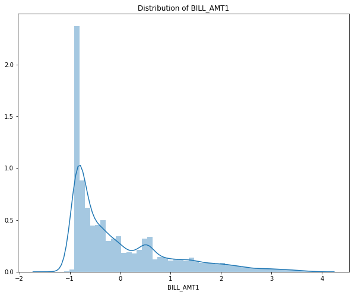

```python
plt.figure(figsize=(10,8))
plt.title('Distribution of BILL_AMT1')
sns.distplot(df_f.BILL_AMT1)
```

Visualizing our classes show us if they are clearly separable and with t-SNE, we can project these higher dimensional distributions into lower-dimensional visualizations. Instead of directly using all features, we select 6 most significant features, which are "PAY_0","PAY_2","PAY_3","PAY_4","PAY_5","PAY_6". In the plot, we can see that fraud data points tend to cluster together, however, some of the fraud data also in that cluster too. It shows that the classifiers may not behave very well since there is no direct boundary and we should carefully choose complexity parameters.

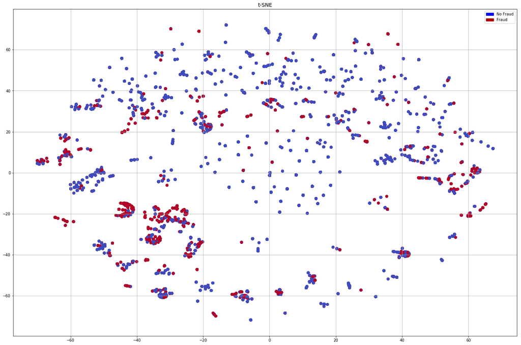

```python
from sklearn.manifold import TSNE
import matplotlib.patches as mpatches
#X = df.iloc[:,:-1]
X = df[["PAY_0","PAY_2","PAY_3","PAY_4","PAY_5","PAY_6"]]
y = df['Class']

X_reduced_tsne = TSNE(n_components=2).fit_transform(X.values)
#t-SNE scatter plot

f, ax = plt.subplots(figsize=(24,16))


blue_patch = mpatches.Patch(color='#0A0AFF', label='No Fraud')
red_patch = mpatches.Patch(color='#AF0000', label='Fraud')

ax.scatter(X_reduced_tsne[:,0], X_reduced_tsne[:,1], c=(y == 0), cmap='coolwarm', label='No Fraud', linewidths=2)
ax.scatter(X_reduced_tsne[:,0], X_reduced_tsne[:,1], c=(y == 1), cmap='coolwarm', label='Fraud', linewidths=2)
ax.set_title('t-SNE', fontsize=14)

ax.grid(True)

ax.legend(handles=[blue_patch, red_patch])
```

split data -> train/ test

```python
#we will use X_train and Y_train for modelling
X_train, X_test, Y_train, Y_test = train_test_split(df_f, df_l,train_size=0.80,random_state=898)
```

```python
print("No of training Examples : "+str(X_train.shape[0]))  # 80% data
print("No of test Examples : "+str(X_test.shape[0]))       # 20% data
```

```
No of training Examples : 20986
No of test Examples : 5247
```

## Model

### Logistic regression

```python
#Logistic Regression
cval = [0.0001, 0.001, 1,10, 100, 1000]
for c in cval:
    log_reg = LogisticRegression(C=c, solver='lbfgs', max_iter = 10000)
    acc_10cv = np.mean(cross_val_score(log_reg, df_f, df_l, cv=10))
    print (c,acc_10cv)
#choose best lamda value with highest accuracy as complexity parameter
#log_reg.fit(X_train,Y_train)
```

```
0.0001 0.7817090679531468
0.001 0.8000431201687727
1 0.8060472046459971
10 0.8060472046459971
100 0.8060472046459971
1000 0.8060472046459971
```

When we choose regarding accuracy, take c = 1, the accuracy is the best

```python
cval = [0.0001, 0.001, 1,10, 100, 1000]
for c in cval:
    log_reg = LogisticRegression(C=c, solver='lbfgs', max_iter = 10000)
    pre_10cv = np.mean(cross_val_score(log_reg, df_f, df_l, cv=10,scoring='precision'))
    print (c,pre_10cv)
#choose best lamda value with highest precision as complexity parameter
#log_reg.fit(X_train,Y_train)
```

```
0.0001 0.7119693999957158
0.001 0.6984941960672697
1 0.6902537648793386
10 0.6902537648793386
100 0.6902537648793386
1000 0.6902537648793386
```

When we choose regarding precision, take c = 0.0001, the precision is the best

### Decision Tree

```python
def cv_eval( max_d, min_leaf, x_train, y_train ):
    dt_clf = DecisionTreeClassifier(criterion='entropy', max_depth=max_d, min_samples_leaf=min_leaf)
    cv10_acc = np.mean(cross_val_score(dt_clf, x_train, y_train, cv=10))

    return cv10_acc
```

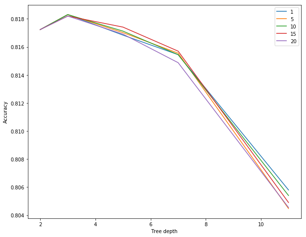

```python
#Decision Tree
depths_list = [2, 3, 5, 7, 11]
min_leaf_size_list = [1, 5,10,15,20]

# We will use a dataframe because it has a simple-to-use plotting function.
dframe = pd.DataFrame(index=depths_list, columns=min_leaf_size_list)

for v in min_leaf_size_list:  # This loop controls the different lines
    l = []
    for d in depths_list:

        # Use the cv_eval() method that we implemented. Pass the parameters in the right order
        acc = cv_eval( d, v, df_f, df_l )
        l.append(acc)

    dframe[v] = l  #Store the result to the dataframe for the particular line

# We can plot the contents of a dataframe with the plot() method
ax = dframe.plot()
ax.set_xlabel("Tree depth")
ax.set_ylabel("Accuracy")
```

When we choose regarding accuracy, from the figure, we choose max_depth=3 since it yields the best cross-validation accuracy, so I expect good generalization performance, and min_leaf_size = 15

```python
def cv_eval_pre( max_d, min_leaf, x_train, y_train ):
    dt_clf = DecisionTreeClassifier(criterion='entropy', max_depth=max_d, min_samples_leaf=min_leaf)
    cv10_acc = np.mean(cross_val_score(dt_clf, x_train, y_train, cv=10,scoring='precision'))

    return cv10_acc
```

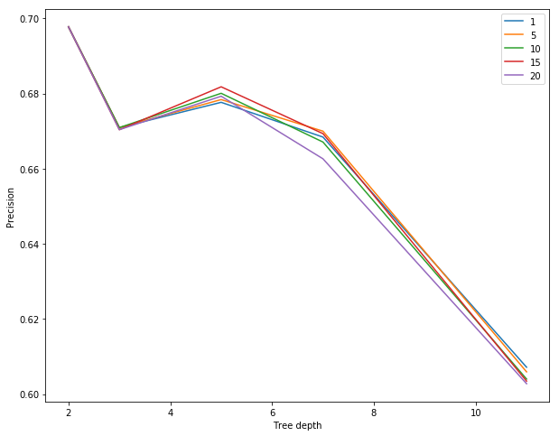

```python
#Decision Tree
depths_list = [2, 3, 5, 7, 11]
min_leaf_size_list = [1, 5,10,15,20]

# We will use a dataframe because it has a simple-to-use plotting function.
dframe = pd.DataFrame(index=depths_list, columns=min_leaf_size_list)

for v in min_leaf_size_list:  # This loop controls the different lines
    l = []
    for d in depths_list:

        # Use the cv_eval() method that we implemented. Pass the parameters in the right order
        acc = cv_eval_pre( d, v, df_f, df_l )
        l.append(acc)

    dframe[v] = l  #Store the result to the dataframe for the particular line

# We can plot the contents of a dataframe with the plot() method
ax = dframe.plot()
ax.set_xlabel("Tree depth")
ax.set_ylabel("Precision")
```

When we choose regarding precision, from the figure, we choose max_depth=2 since it yields the best cross-validation precision, so I expect good generalization performance, and min_leaf_size = 15

```python
tree_clf = DecisionTreeClassifier(max_depth=5, criterion="entropy",min_samples_leaf=15)
tree_clf.fit(df_f, df_l)
```

[output not shown]

### Random Forest

```python
ranfor_model = RandomForestClassifier(n_estimators=100, max_depth=2,random_state=0)
ranfor_model.fit(X_test,Y_test)
#print(ranfor_model.feature_importances_)
print ("Accuracy is %.3f" % (metrics.accuracy_score(Y_test, ranfor_model.predict(X_test))))
print ("Precision is %.3f" % (metrics. precision_score(Y_test, ranfor_model.predict(X_test))))
```

```
Accuracy is 0.805
Precision is 0.759
```

```python
def cv_eval_acc( n_est, max_depth, x_train, y_train ):
    ranfor_model = RandomForestClassifier(n_estimators=n_est, max_depth=max_depth,random_state=0)
    cv10_acc = np.mean(cross_val_score(ranfor_model, x_train, y_train, cv=10))
    return cv10_acc
```

```
[0.8050725904282677, 0.8022154384603086, 0.8136491426949701, 0.8093624598156062, 0.8068643685316053]
[0.8041790921117187, 0.8045371944516952, 0.8093567188625329, 0.8100741945013491, 0.809181337358492]
[0.8048946567568318, 0.8091800629830728, 0.8129319785321837, 0.8138267523630042, 0.8123981797955807]
[0.8041800493168484, 0.8079291035002389, 0.8134673779253122, 0.8129342135292887, 0.8111456242116295]
[0.8036430561003064, 0.8066787817745411, 0.8111459447984757, 0.8120410369384377, 0.8095378413196471]
```

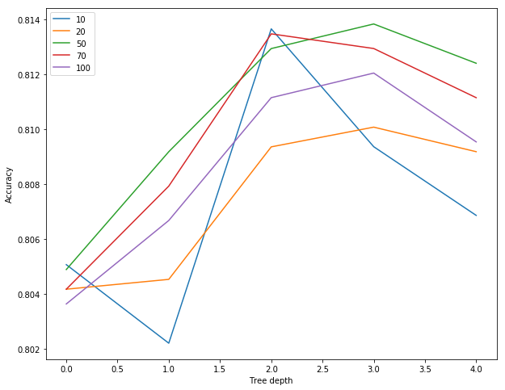

```python
#Random Forest control regarding accuracy
n_est = [10,20,50,70,100]
max_depth = [2,3,5,6,7]
# We will use a dataframe because it has a simple-to-use plotting function.
dframe = pd.DataFrame()
for n in n_est:
    l = []
    for m in max_depth:

        acc = cv_eval_acc(n, m, X_test, Y_test)
        l.append(acc)
    print(l)
    dframe[n] = l  #Store the result to the dataframe for the particular line

# We can plot the contents of a dataframe with the plot() method
ax = dframe.plot()
ax.set_xlabel("Tree depth")
ax.set_ylabel("Accuracy")
```

We should choose n = 50, depth = 6

```python
def cv_eval_pre( n_est, max_depth, x_train, y_train ):
    ranfor_model = RandomForestClassifier(n_estimators=n_est, max_depth=max_depth,random_state=0)
    cv10_acc = np.mean(cross_val_score(ranfor_model, x_train, y_train, cv=10,scoring='precision'))
    return cv10_acc
```

```
[0.7234030740382826, 0.6686040705649161, 0.6992360738959592, 0.6679325207971161, 0.64122178476362]
[0.7274921821866254, 0.6970731470273804, 0.6876836274382057, 0.6714380592952022, 0.6496937371970467]
[0.7246105964680949, 0.7237327604348881, 0.6786413466510377, 0.6839641266051449, 0.6673343145232288]
[0.7248774297577676, 0.719291349232459, 0.696129728451377, 0.6756708114726753, 0.6630614036781725]
[0.7424059507624581, 0.7112397953344203, 0.6892350884763572, 0.670282454773598, 0.6573042710322927]
```

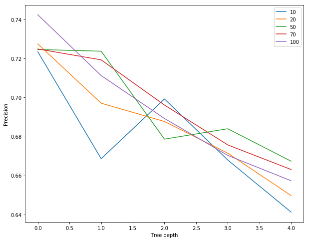

```python
#Random Forest
n_est = [10,20,50,70,100]
max_depth = [2,3,5,6,7]
# We will use a dataframe because it has a simple-to-use plotting function.
dframe = pd.DataFrame()
for n in n_est:
    l = []
    for m in max_depth:

        acc = cv_eval_pre(n, m, X_test, Y_test)
        l.append(acc)
    print(l)
    dframe[n] = l  #Store the result to the dataframe for the particular line

# We can plot the contents of a dataframe with the plot() method
ax = dframe.plot()
ax.set_xlabel("Tree depth")
ax.set_ylabel("Precision")
```

### Bagging meta-estimator

```python
#Bagging meta-estimator - ensemble algorithm to make prediction
modelT = BaggingClassifier(tree.DecisionTreeClassifier(random_state=1))
modelT.fit(X_train, Y_train)
modelT.score(X_test,Y_test)
```

[output not shown]

### KNN

```python
model_KNN = KNeighborsClassifier(10, weights='distance')
model_KNN.fit(X_test, Y_test)
```

```
KNeighborsClassifier(algorithm='auto', leaf_size=30, metric='minkowski',
           metric_params=None, n_jobs=None, n_neighbors=10, p=2,
           weights='distance')
```

```python
for k in [5,10, 20,50,70,80,90,100]:
    model = KNeighborsClassifier(k, weights='distance')
    model.fit(X_train, Y_train)
    print ("Accuracy with k = %d is %.3f" % (k, metrics.accuracy_score(Y_test, model.predict(X_test))) )
```

```
Accuracy with k = 5 is 0.787
Accuracy with k = 10 is 0.799
Accuracy with k = 20 is 0.808
Accuracy with k = 50 is 0.807
Accuracy with k = 70 is 0.807
Accuracy with k = 80 is 0.805
Accuracy with k = 90 is 0.804
Accuracy with k = 100 is 0.804
```

When we choose regarding accuracy, we choose k = 20 to achieve the best performance as well as avoid overfiting.

```python
for k in [5,10, 20,50,70,80,90,100]:
    model = KNeighborsClassifier(k, weights='distance')
    model.fit(X_train, Y_train)
    print ("Precision with k = %d is %.3f" % (k, metrics.precision_score(Y_test, model.predict(X_test))) )
```

```
Precision with k = 5 is 0.532
Precision with k = 10 is 0.584
Precision with k = 20 is 0.630
Precision with k = 50 is 0.644
Precision with k = 70 is 0.647
Precision with k = 80 is 0.641
Precision with k = 90 is 0.636
Precision with k = 100 is 0.637
```

When we choose regarding precision, we choose k = 70 to achieve the best performance as well as avoid overfitting

### bagging ensemble of KNN

```python
#bagging ensemble of KNN base estimators on random subsets of 50% of samples and 50% of features
modelK = BaggingClassifier(KNeighborsClassifier(), max_samples=0.5, max_features=0.5)
modelK.fit(X_train, Y_train)

print ("Accuracy is %.3f" % (metrics.accuracy_score(Y_test, modelK.predict(X_test))))
print ("Precision is %.3f" % (metrics. precision_score(Y_test, modelK.predict(X_test))))
```

```
Accuracy is 0.808
Precision is 0.654
```

### SVM

```python
from dstools import data_tools
plt.figure(figsize=[10,9])

# Let's learn a Linear Support Vector Machine. You can also try an SVC instead of LinearSVC
svm_model = svm.LinearSVC(C=0.1, max_iter=100000)  # Try the following model: svm.SVC(gamma='scale', max_iter=100000)
svm_model.fit(X_test, Y_test)
```

```
LinearSVC(C=0.1, class_weight=None, dual=True, fit_intercept=True,
     intercept_scaling=1, loss='squared_hinge', max_iter=100000,
     multi_class='ovr', penalty='l2', random_state=None, tol=0.0001,
     verbose=0)
```

```python
print ("Accuracy is %.3f" % (metrics.accuracy_score(Y_test, svm_model.predict(X_test))))
print ("Precision is %.3f" % (metrics. precision_score(Y_test, svm_model.predict(X_test))))
```

```
Accuracy is 0.803
Precision is 0.748
```

## Evaluation part

### choosing parameter regarding optimize precision

```python
#train model 1, with max_depth = 5
tree_clf = DecisionTreeClassifier(criterion='entropy', max_depth=2,min_samples_leaf=15)
tree_clf.fit(X_train, Y_train)

#train model 2, with c = 1
log_reg = LogisticRegression(C=0.0001,solver='lbfgs')
log_reg.fit(X_train, Y_train)

#train model 3, with k = 80 to be modified
knn_model = KNeighborsClassifier(70, weights='distance')
knn_model.fit(X_train, Y_train)

#train model modelK
modelK = BaggingClassifier(KNeighborsClassifier(), max_samples=0.5, max_features=0.5)
modelK.fit(X_train, Y_train)

#train random_forest
ranfor_model = RandomForestClassifier(n_estimators=50, max_depth=3,random_state=0)
ranfor_model.fit(X_train, Y_train)

#train model modelT
modelT = BaggingClassifier(tree.DecisionTreeClassifier(random_state=1))
modelT.fit(X_train, Y_train)

#train SVM
#svm_model = svm.LinearSVC(C=0.1, max_iter=100000)
svm_model = svm.SVC(C=0.1, max_iter=100000,probability=True,class_weight='balanced') # Try the following model: svm.SVC(gamma='scale', max_iter=100000)
svm_model.fit(X_test, Y_test)
```

```
SVC(C=0.1, cache_size=200, class_weight='balanced', coef0=0.0,
  decision_function_shape='ovr', degree=3, gamma='auto_deprecated',
  kernel='rbf', max_iter=100000, probability=True, random_state=None,
  shrinking=True, tol=0.001, verbose=False)
```

```python
acc_list = []
acc_tree = metrics.accuracy_score(modelT.predict(X_test), Y_test)
acc_list.append(acc_tree)

acc_tree_2 = metrics.accuracy_score(tree_clf.predict(X_test), Y_test)
acc_list.append(acc_tree_2)

acc_log = metrics.accuracy_score(log_reg.predict(X_test), Y_test)
acc_list.append(acc_log)

acc_knn = metrics.accuracy_score(knn_model.predict(X_test), Y_test)
acc_list.append(acc_knn)

acc_knn_2 = metrics.accuracy_score(modelK.predict(X_test), Y_test)
acc_list.append(acc_knn_2)

acc_svm =  metrics.accuracy_score(svm_model.predict(X_test), Y_test)
acc_list.append(acc_svm)

acc_ran = metrics.accuracy_score(ranfor_model.predict(X_test), Y_test)
acc_list.append(acc_ran)


for i in range (len(acc_list)):
    print ("Accuracy of model %d is %.3f" % ((i+1), acc_list[i]))
```

```
Accuracy of model 1 is 0.803
Accuracy of model 2 is 0.816
Accuracy of model 3 is 0.783
Accuracy of model 4 is 0.807
Accuracy of model 5 is 0.803
Accuracy of model 6 is 0.792
Accuracy of model 7 is 0.812
```

Highest accuracy is get be Decision Tree model.

**Percision** ---LOW--- to much FP--- how to improve?

```python
precision = []
acc_tree = metrics.precision_score(Y_test,modelT.predict(X_test))
precision.append(acc_tree)

acc_tree_2 = metrics.precision_score(Y_test,tree_clf.predict(X_test))
precision.append(acc_tree_2)

acc_log = metrics.precision_score( Y_test,log_reg.predict(X_test))
precision.append(acc_log)

acc_knn = metrics.precision_score(Y_test,knn_model.predict(X_test))
precision.append(acc_knn)

acc_knn_2 = metrics.precision_score(Y_test,modelK.predict(X_test))
precision.append(acc_knn_2)

acc_svm =  metrics. precision_score(Y_test, svm_model.predict(X_test))
precision.append(acc_svm)


acc_ran = metrics.precision_score(Y_test, ranfor_model.predict(X_test))
precision.append(acc_ran)


for i in range (len(precision)):
    print ("Precision of model %d is %.3f" % ((i+1), precision[i]))
```

```
Precision of model 1 is 0.588
Precision of model 2 is 0.705
Precision of model 3 is 0.661
Precision of model 4 is 0.647
Precision of model 5 is 0.626
Precision of model 6 is 0.518
Precision of model 7 is 0.684
```

Highest precision is the Decision Tree model

```python
recall = []
acc_tree = metrics.recall_score(Y_test,modelT.predict(X_test))
recall.append(acc_tree)

acc_tree_2 = metrics.recall_score(Y_test,tree_clf.predict(X_test))
recall.append(acc_tree_2)

acc_log = metrics.recall_score( Y_test,log_reg.predict(X_test))
recall.append(acc_log)

acc_knn = metrics.recall_score(Y_test,knn_model.predict(X_test))
recall.append(acc_knn)

acc_knn_2 = metrics.recall_score(Y_test,modelK.predict(X_test))
recall.append(acc_knn_2)

acc_svm =  metrics. recall_score(Y_test, svm_model.predict(X_test))
recall.append(acc_svm)

acc_ran = metrics.recall_score(Y_test, ranfor_model.predict(X_test))
recall.append(acc_ran)


for i in range (len(recall)):
    print ("recall of model %d is %.3f" % ((i+1), recall[i]))
```

```
recall of model 1 is 0.347
recall of model 2 is 0.302
recall of model 3 is 0.034
recall of model 4 is 0.273
recall of model 5 is 0.252
recall of model 6 is 0.536
recall of model 7 is 0.265
```

**Confusion Matrix**

```python
conf_mtx = metrics.confusion_matrix(Y_test, tree_clf.predict(X_test), labels=[1, 0])
conf_mtx_df = pd.DataFrame(conf_mtx.T, columns=['(True) p', '(True) n'], index=['[Predicted] Y', '[Predicted] N'])
conf_mtx_df
```

[output not shown]

```python
conf_mtx = metrics.confusion_matrix(Y_test, log_reg.predict(X_test), labels=[1, 0])
conf_mtx_df = pd.DataFrame(conf_mtx.T, columns=['(True) p', '(True) n'], index=['[Predicted] Y', '[Predicted] N'])
conf_mtx_df
```

[output not shown]

need to adjust threshold!!!

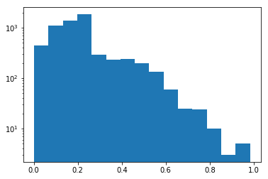

```python
# Get probabilities that an item belongs to class=1
probabilities = log_reg.predict_proba(X_test)[:, 1]

plt.figure()
plt.hist(probabilities, bins=15, range=(min(probabilities), max(probabilities)), log=True)
plt.show()
```

```python
# *We* get to choose the value
threshold = 0.25

# The `probabilities` variable is of np.array type.
# Anything above the threshold belongs to class 1, otherwise to class 0
thresh_predictions = (probabilities > threshold).astype(int)

# Let's print the predictions again
thresh_predictions
```

```
array([0, 1, 0, ..., 0, 0, 1])
```

```python
# Compute the confusion matrix with the thresholded predictions!
conf_mtx = metrics.confusion_matrix(Y_test, thresh_predictions, labels=[1, 0])

# Like before, once we have the matrix, we convert it to a dataframe for a nicer visualization
conf_mtx_df = pd.DataFrame(conf_mtx.T, columns=['(True) p', '(True) n'], index=['[Predicted] Y', '[Predicted] N'])
conf_mtx_df
```

[output not shown]

```python
conf_mtx = metrics.confusion_matrix(Y_test, knn_model.predict(X_test), labels=[1, 0])
conf_mtx_df = pd.DataFrame(conf_mtx.T, columns=['(True) p', '(True) n'], index=['[Predicted] Y', '[Predicted] N'])
conf_mtx_df
```

[output not shown]

Re-train the logistic regression model with threshold =0.25

```python
pred_proba_df =log_reg.predict_proba(X_test)[:,1]
pred_proba = []
for i in range(len(pred_proba_df)):
    if pred_proba_df[i]>0.25:
        pred_proba.append(1)
    else:
        pred_proba.append(0)
pred_proba_df
type(pred_proba_df)
```

```
numpy.ndarray
```

```python
recall = []
acc_tree = metrics.recall_score(Y_test,modelT.predict(X_test))
recall.append(acc_tree)

acc_tree_2 = metrics.recall_score(Y_test,tree_clf.predict(X_test))
recall.append(acc_tree_2)

acc_log = metrics.recall_score( Y_test,pred_proba)
recall.append(acc_log)

acc_knn = metrics.recall_score(Y_test,knn_model.predict(X_test))
recall.append(acc_knn)

acc_knn_2 = metrics.recall_score(Y_test,modelK.predict(X_test))
recall.append(acc_knn_2)

acc_svm =  metrics. recall_score(Y_test, svm_model.predict(X_test))
recall.append(acc_svm)

acc_ran = metrics.recall_score(Y_test, ranfor_model.predict(X_test))
recall.append(acc_ran)


for i in range (len(recall)):
    print ("recall of model %d is %.3f" % ((i+1), recall[i]))
```

```
recall of model 1 is 0.347
recall of model 2 is 0.302
recall of model 3 is 0.537
recall of model 4 is 0.273
recall of model 5 is 0.252
recall of model 6 is 0.536
recall of model 7 is 0.265
```

**Fβ score**

$$precision = \frac{TP}{TP + FP}$$$$F_\beta = (1 + \beta^2) \frac{\text{precision} \times \text{recall}}{\beta^2 \text{precision} + \text{recall}}.$$

```python
fbeta_1 = fbeta_score(Y_test, tree_clf.predict(X_test), beta = 0.5)
print ("Fβ score of model decision tree is %.3f" % (fbeta_1))

fbeta_2 = fbeta_score(Y_test, modelT.predict(X_test), beta = 0.5)
print ("Fβ score of model model T is %.3f" % (fbeta_2))

#fbeta_3 = fbeta_score(Y_test, log_reg.predict(X_test), beta = 0.5)
fbeta_3 = fbeta_score(Y_test, pred_proba, beta = 0.5)
print ("Fβ score of model log reg is %.3f" % (fbeta_3))

fbeta_4 = fbeta_score(Y_test, knn_model.predict(X_test), beta = 0.5)
print ("Fβ score of model KNN is %.3f" % (fbeta_4))

fbeta_5 = fbeta_score(Y_test, modelK.predict(X_test), beta = 0.5)
print ("Fβ score of model K is %.3f" % (fbeta_5))

fbeta_6 = fbeta_score(Y_test, svm_model.predict(X_test), beta = 0.5)
print ("Fβ score of model SVM is %.3f" % (fbeta_6))

fbeta_7 = fbeta_score(Y_test, ranfor_model.predict(X_test), beta = 0.5)
print ("Fβ score of model Random Forest is %.3f" % (fbeta_7))
```

```
Fβ score of model decision tree is 0.548
Fβ score of model model T is 0.520
Fβ score of model log reg is 0.446
Fβ score of model KNN is 0.510
Fβ score of model K is 0.489
Fβ score of model SVM is 0.531
Fβ score of model Random Forest is 0.524
```

**2. Compare the AUC**

```python
# For each instance in the TEST DATA, get the probability that it belongs to the POSITIVE class (LEAVE=1)
Y_test_probability_1 = tree_clf.predict_proba(X_test)[:, 1]
Y_test_probability_2 = modelT.predict_proba(X_test)[:, 1]
Y_test_probability_3 = log_reg.predict_proba(X_test)[:, 1]
Y_test_probability_4 = knn_model.predict_proba(X_test)[:, 1]
Y_test_probability_5 = modelK.predict_proba(X_test)[:, 1]
Y_test_probability_6 = svm_model.predict_proba(X_test)[:, 1]
Y_test_probability_7 = ranfor_model.predict_proba(X_test)[:, 1]
```

```python
# Use the roc_curve method to generate FPR and TPR
fpr_1, tpr_1, thresholds_1 = metrics.roc_curve(Y_test, Y_test_probability_1)
fpr_2, tpr_2, thresholds_2 = metrics.roc_curve(Y_test, Y_test_probability_2)
fpr_3, tpr_3, thresholds_3 = metrics.roc_curve(Y_test, Y_test_probability_3)
fpr_4, tpr_4, thresholds_4 = metrics.roc_curve(Y_test, Y_test_probability_4)
fpr_5, tpr_5, thresholds_5 = metrics.roc_curve(Y_test, Y_test_probability_5)
fpr_6, tpr_6, thresholds_6 = metrics.roc_curve(Y_test, Y_test_probability_6)
fpr_7, tpr_7, thresholds_7 = metrics.roc_curve(Y_test, Y_test_probability_7)
```

```python
# Compute the AUC for the ROC
auc_1 = metrics.roc_auc_score(Y_test, Y_test_probability_1)
auc_2 = metrics.roc_auc_score(Y_test, Y_test_probability_2)
auc_3 = metrics.roc_auc_score(Y_test, Y_test_probability_3)
auc_4 = metrics.roc_auc_score(Y_test, Y_test_probability_4)
auc_5 = metrics.roc_auc_score(Y_test, Y_test_probability_5)
auc_6 = metrics.roc_auc_score(Y_test, Y_test_probability_6)
auc_7 = metrics.roc_auc_score(Y_test, Y_test_probability_7)
```

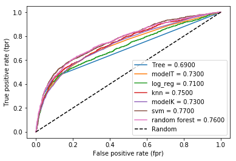

```python
plt.plot(fpr_1, tpr_1, label="Tree = %.4f" % round(auc_1, 2))
plt.plot(fpr_2, tpr_2, label="modelT = %.4f" % round(auc_2, 2))
plt.plot(fpr_3, tpr_3, label="log_reg = %.4f" % round(auc_3, 2))
plt.plot(fpr_4, tpr_4, label="knn = %.4f" % round(auc_4, 2))
plt.plot(fpr_5, tpr_5, label="modelK = %.4f" % round(auc_5, 2))
plt.plot(fpr_6, tpr_6, label="svm = %.4f" % round(auc_6, 2))
plt.plot(fpr_7, tpr_7, label="random forest = %.4f" % round(auc_7, 2))


plt.xlabel("False positive rate (fpr)")
plt.ylabel("True positive rate (tpr)")
plt.plot([0,1], [0,1], 'k--', label="Random")
plt.legend(loc=0)
```

### choosing parameter regarding optimize accuracy--do we need it?

### Spot-checking algorithms

Spot-checking algorithms is a part of the process of applied machine learning. On a new problem, you need to quickly determine which type or class of algorithms is good at picking out the structure in your problem and which are not.

```python
##Spot-Checking Algorithms
models = []

models.append(('Logreg', LogisticRegression()))
models.append(('Dec Tree', DecisionTreeClassifier()))
models.append(('KNN', KNeighborsClassifier()))
models.append(('K', BaggingClassifier(KNeighborsClassifier())))
models.append(('SVM',svm.SVC()))
models.append(('T', BaggingClassifier(tree.DecisionTreeClassifier())))
models.append(('Ran For', RandomForestClassifier()))

#testing models

results = []
names = []

for name, model in models:
    cv_results = cross_val_score(model, X_train, Y_train, cv=10, scoring='roc_auc')
    results.append(cv_results)
    names.append(name)
    msg = '%s: %f (%f)' % (name, cv_results.mean(), cv_results.std())
    print(msg)
```

```
Logreg: 0.734125 (0.016208)
Dec Tree: 0.612065 (0.013090)
KNN: 0.701131 (0.012861)
K: 0.712390 (0.010166)
```

```
SVM: 0.723274 (0.014164)
T: 0.730653 (0.012779)
```

```
Ran For: 0.728675 (0.012315)
```

The results of this spot-checking can be visualized as:

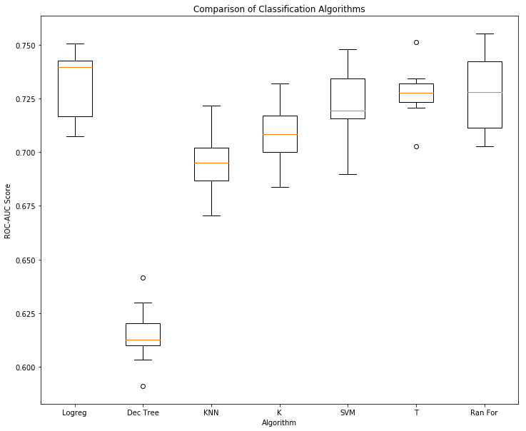

```python
#Compare Algorithms

fig = plt.figure(figsize=(12,10))
plt.title('Comparison of Classification Algorithms')
plt.xlabel('Algorithm')
plt.ylabel('ROC-AUC Score')
plt.boxplot(results)
ax = fig.add_subplot(111)
ax.set_xticklabels(names)
plt.show()
```